# Risk Factor Analysis

## Outcome Variable

**Outcome Variable:** stunted

## Predictor Variables

**Intervention Variable:** tr

**Adjustment Set:**

unadjusted

## Stratifying Variables

The analysis was stratified on these variable(s):

- impfloor
- agecat
- studyid
- country

## Data Summary

| impfloor | agecat | studyid | country | tr | stunted | n_cell | n |
| --- | --- | --- | --- | --- | --- | --- | --- |
| 1 | 24 months | ki1000110-WASH-Bangladesh | BANGLADESH | Control | 0 | 33 | 154 |
| 1 | 24 months | ki1000110-WASH-Bangladesh | BANGLADESH | Control | 1 | 6 | 154 |
| 1 | 24 months | ki1000110-WASH-Bangladesh | BANGLADESH | LNS | 0 | 30 | 154 |
| 1 | 24 months | ki1000110-WASH-Bangladesh | BANGLADESH | LNS | 1 | 9 | 154 |
| 1 | 24 months | ki1000110-WASH-Bangladesh | BANGLADESH | Other | 0 | 56 | 154 |
| 1 | 24 months | ki1000110-WASH-Bangladesh | BANGLADESH | Other | 1 | 20 | 154 |
| 1 | 6 months | ki1000110-WASH-Bangladesh | BANGLADESH | Control | 0 | 15 | 78 |
| 1 | 6 months | ki1000110-WASH-Bangladesh | BANGLADESH | Control | 1 | 1 | 78 |
| 1 | 6 months | ki1000110-WASH-Bangladesh | BANGLADESH | LNS | 0 | 15 | 78 |
| 1 | 6 months | ki1000110-WASH-Bangladesh | BANGLADESH | LNS | 1 | 3 | 78 |
| 1 | 6 months | ki1000110-WASH-Bangladesh | BANGLADESH | Other | 0 | 43 | 78 |
| 1 | 6 months | ki1000110-WASH-Bangladesh | BANGLADESH | Other | 1 | 1 | 78 |
| 0 | 24 months | ki1000111-WASH-Kenya | KENYA | Control | 0 | 493 | 2141 |
| 0 | 24 months | ki1000111-WASH-Kenya | KENYA | Control | 1 | 224 | 2141 |
| 0 | 24 months | ki1000111-WASH-Kenya | KENYA | LNS | 0 | 335 | 2141 |
| 0 | 24 months | ki1000111-WASH-Kenya | KENYA | LNS | 1 | 140 | 2141 |
| 0 | 24 months | ki1000111-WASH-Kenya | KENYA | Other | 0 | 638 | 2141 |
| 0 | 24 months | ki1000111-WASH-Kenya | KENYA | Other | 1 | 311 | 2141 |
| 0 | 6 months | ki1000111-WASH-Kenya | KENYA | Control | 0 | 22 | 72 |
| 0 | 6 months | ki1000111-WASH-Kenya | KENYA | Control | 1 | 2 | 72 |
| 0 | 6 months | ki1000111-WASH-Kenya | KENYA | LNS | 0 | 11 | 72 |
| 0 | 6 months | ki1000111-WASH-Kenya | KENYA | LNS | 1 | 3 | 72 |
| 0 | 6 months | ki1000111-WASH-Kenya | KENYA | Other | 0 | 28 | 72 |
| 0 | 6 months | ki1000111-WASH-Kenya | KENYA | Other | 1 | 6 | 72 |
| 1 | 24 months | ki1000111-WASH-Kenya | KENYA | Control | 0 | 34 | 122 |
| 1 | 24 months | ki1000111-WASH-Kenya | KENYA | Control | 1 | 8 | 122 |
| 1 | 24 months | ki1000111-WASH-Kenya | KENYA | LNS | 0 | 19 | 122 |
| 1 | 24 months | ki1000111-WASH-Kenya | KENYA | LNS | 1 | 6 | 122 |
| 1 | 24 months | ki1000111-WASH-Kenya | KENYA | Other | 0 | 46 | 122 |
| 1 | 24 months | ki1000111-WASH-Kenya | KENYA | Other | 1 | 9 | 122 |

[output cut: 87 more lines]

The following strata were considered:

- impfloor: 0, agecat: 24 months, studyid: ki1000111-WASH-Kenya, country: KENYA
- impfloor: 0, agecat: 24 months, studyid: kiGH5241-JiVitA-3, country: BANGLADESH
- impfloor: 0, agecat: 24 months, studyid: kiGH5241-JiVitA-4, country: BANGLADESH
- impfloor: 0, agecat: 6 months, studyid: ki1000111-WASH-Kenya, country: KENYA
- impfloor: 0, agecat: 6 months, studyid: ki1000125-AgaKhanUniv, country: PAKISTAN
- impfloor: 0, agecat: 6 months, studyid: ki1000304-VITAMIN-A, country: INDIA
- impfloor: 0, agecat: 6 months, studyid: ki1017093b-PROVIDE, country: BANGLADESH
- impfloor: 0, agecat: 6 months, studyid: kiGH5241-JiVitA-3, country: BANGLADESH
- impfloor: 0, agecat: 6 months, studyid: kiGH5241-JiVitA-4, country: BANGLADESH
- impfloor: 0, agecat: Birth, studyid: ki1000125-AgaKhanUniv, country: PAKISTAN
- impfloor: 0, agecat: Birth, studyid: kiGH5241-JiVitA-3, country: BANGLADESH
- impfloor: 0, agecat: Birth, studyid: kiGH5241-JiVitA-4, country: BANGLADESH
- impfloor: 1, agecat: 24 months, studyid: ki1000110-WASH-Bangladesh, country: BANGLADESH
- impfloor: 1, agecat: 24 months, studyid: ki1000111-WASH-Kenya, country: KENYA
- impfloor: 1, agecat: 24 months, studyid: ki1000125-AgaKhanUniv, country: PAKISTAN
- impfloor: 1, agecat: 24 months, studyid: ki1017093b-PROVIDE, country: BANGLADESH
- impfloor: 1, agecat: 24 months, studyid: kiGH5241-JiVitA-3, country: BANGLADESH
- impfloor: 1, agecat: 24 months, studyid: kiGH5241-JiVitA-4, country: BANGLADESH
- impfloor: 1, agecat: 6 months, studyid: ki1000110-WASH-Bangladesh, country: BANGLADESH
- impfloor: 1, agecat: 6 months, studyid: ki1000111-WASH-Kenya, country: KENYA
- impfloor: 1, agecat: 6 months, studyid: ki1000125-AgaKhanUniv, country: PAKISTAN
- impfloor: 1, agecat: 6 months, studyid: ki1017093b-PROVIDE, country: BANGLADESH
- impfloor: 1, agecat: 6 months, studyid: kiGH5241-JiVitA-3, country: BANGLADESH
- impfloor: 1, agecat: 6 months, studyid: kiGH5241-JiVitA-4, country: BANGLADESH
- impfloor: 1, agecat: Birth, studyid: ki1000125-AgaKhanUniv, country: PAKISTAN
- impfloor: 1, agecat: Birth, studyid: kiGH5241-JiVitA-3, country: BANGLADESH
- impfloor: 1, agecat: Birth, studyid: kiGH5241-JiVitA-4, country: BANGLADESH

### Dropped Strata

Some strata were dropped due to rare outcomes:

- impfloor: 1, agecat: 6 months, studyid: ki1000110-WASH-Bangladesh, country: BANGLADESH
- impfloor: 0, agecat: 6 months, studyid: ki1000111-WASH-Kenya, country: KENYA
- impfloor: 1, agecat: 6 months, studyid: ki1000111-WASH-Kenya, country: KENYA
- impfloor: 1, agecat: 24 months, studyid: ki1000125-AgaKhanUniv, country: PAKISTAN
- impfloor: 1, agecat: Birth, studyid: ki1000125-AgaKhanUniv, country: PAKISTAN
- impfloor: 0, agecat: Birth, studyid: ki1000125-AgaKhanUniv, country: PAKISTAN
- impfloor: 1, agecat: 6 months, studyid: ki1017093b-PROVIDE, country: BANGLADESH
- impfloor: 0, agecat: 6 months, studyid: ki1017093b-PROVIDE, country: BANGLADESH
- impfloor: 1, agecat: 24 months, studyid: ki1017093b-PROVIDE, country: BANGLADESH
- impfloor: 1, agecat: 24 months, studyid: kiGH5241-JiVitA-3, country: BANGLADESH

## Methods Detail

We’re interested in the causal parameters $E[Y_a]$ for all values of $a \in \mathcal{A}$. These parameters represent the mean outcome if, possibly contrary to fact, we intervened to set all units to have $A=a$. Under the randomization and positivity assumptions, these are identified by the statistical parameters $\psi_a=E_W[E_{Y|A,W}(Y|A=a,W)]$. In addition, we’re interested in the mean of $Y$, $E[Y]$ under no intervention (the observed mean). We will estimate these parameters by using SuperLearner to fit the relevant likelihood factors – $E_{Y|A,W}(Y|A=a,W)$ and $p(A=a|W)$, and then updating our likelihood fit using a joint TMLE.

For unadjusted analyses ($W=\{\}$), initial likelihoods were estimated using Lrnr_glm to estimate the simple $E(Y|A)$ and Lrnr_mean to estimate $p(A)$. For adjusted analyses, a small library containing Lrnr_glmnet, Lrnr_xgboost, and Lrnr_mean was used.

Having estimated these parameters, we will then use the delta method to estimate relative risks and attributable risks relative to a prespecified baseline level of $A$.

# Results Detail

## Results Plots

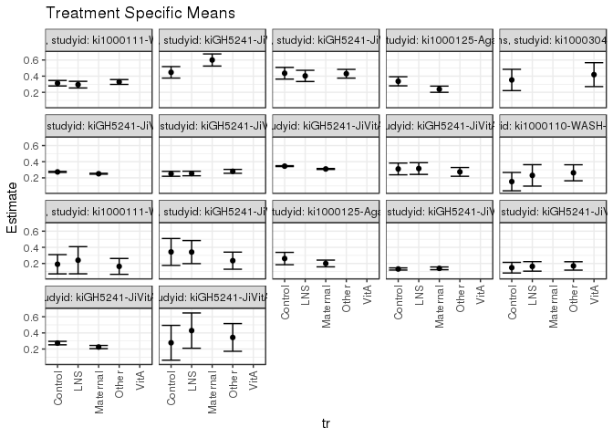

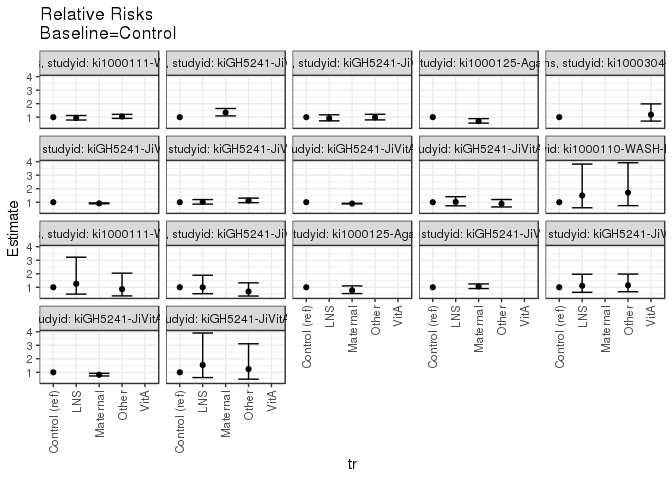

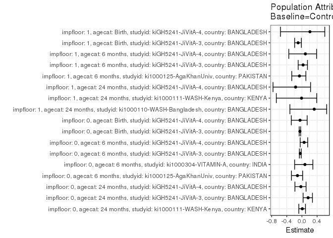

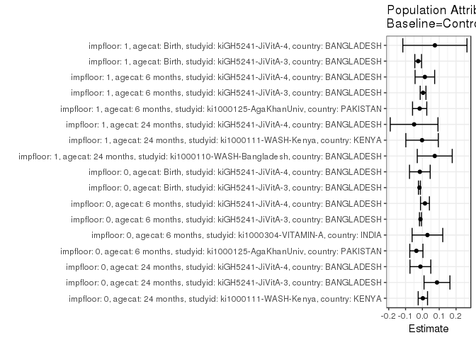

## Results Table

### Parameter: TSM

| impfloor | agecat | studyid | country | intervention_level | baseline_level | estimate | ci_lower | ci_upper |
| --- | --- | --- | --- | --- | --- | --- | --- | --- |
| 0 | Birth | kiGH5241-JiVitA-3 | BANGLADESH | Control | NA | 0.3452031 | 0.3397106 | 0.3506956 |
| 0 | Birth | kiGH5241-JiVitA-3 | BANGLADESH | Maternal | NA | 0.3104041 | 0.3048441 | 0.3159641 |
| 0 | Birth | kiGH5241-JiVitA-4 | BANGLADESH | Control | NA | 0.3106796 | 0.2379782 | 0.3833810 |
| 0 | Birth | kiGH5241-JiVitA-4 | BANGLADESH | LNS | NA | 0.3155340 | 0.2429658 | 0.3881021 |
| 0 | Birth | kiGH5241-JiVitA-4 | BANGLADESH | Other | NA | 0.2743363 | 0.2202431 | 0.3284295 |
| 0 | 6 months | ki1000125-AgaKhanUniv | PAKISTAN | Control | NA | 0.3363636 | 0.2800613 | 0.3926660 |
| 0 | 6 months | ki1000125-AgaKhanUniv | PAKISTAN | Maternal | NA | 0.2380952 | 0.1996841 | 0.2765063 |
| 0 | 6 months | ki1000304-VITAMIN-A | INDIA | Control | NA | 0.3529412 | 0.2210826 | 0.4847998 |
| 0 | 6 months | ki1000304-VITAMIN-A | INDIA | VitA | NA | 0.4186047 | 0.2703617 | 0.5668476 |
| 0 | 6 months | kiGH5241-JiVitA-3 | BANGLADESH | Control | NA | 0.2739383 | 0.2677621 | 0.2801144 |
| 0 | 6 months | kiGH5241-JiVitA-3 | BANGLADESH | Maternal | NA | 0.2511713 | 0.2454276 | 0.2569150 |
| 0 | 6 months | kiGH5241-JiVitA-4 | BANGLADESH | Control | NA | 0.2504521 | 0.2197768 | 0.2811273 |
| 0 | 6 months | kiGH5241-JiVitA-4 | BANGLADESH | LNS | NA | 0.2543403 | 0.2260727 | 0.2826079 |
| 0 | 6 months | kiGH5241-JiVitA-4 | BANGLADESH | Other | NA | 0.2811698 | 0.2571778 | 0.3051618 |
| 0 | 24 months | ki1000111-WASH-Kenya | KENYA | Control | NA | 0.3124128 | 0.2784801 | 0.3463455 |
| 0 | 24 months | ki1000111-WASH-Kenya | KENYA | LNS | NA | 0.2947368 | 0.2537263 | 0.3357474 |
| 0 | 24 months | ki1000111-WASH-Kenya | KENYA | Other | NA | 0.3277134 | 0.2978430 | 0.3575838 |
| 0 | 24 months | kiGH5241-JiVitA-3 | BANGLADESH | Control | NA | 0.4473684 | 0.3762731 | 0.5184638 |
| 0 | 24 months | kiGH5241-JiVitA-3 | BANGLADESH | Maternal | NA | 0.6000000 | 0.5249501 | 0.6750499 |
| 0 | 24 months | kiGH5241-JiVitA-4 | BANGLADESH | Control | NA | 0.4360000 | 0.3637388 | 0.5082612 |
| 0 | 24 months | kiGH5241-JiVitA-4 | BANGLADESH | LNS | NA | 0.4031008 | 0.3336278 | 0.4725738 |
| 0 | 24 months | kiGH5241-JiVitA-4 | BANGLADESH | Other | NA | 0.4298643 | 0.3757685 | 0.4839600 |
| 1 | Birth | kiGH5241-JiVitA-3 | BANGLADESH | Control | NA | 0.2741021 | 0.2525940 | 0.2956101 |
| 1 | Birth | kiGH5241-JiVitA-3 | BANGLADESH | Maternal | NA | 0.2248629 | 0.2051641 | 0.2445617 |
| 1 | Birth | kiGH5241-JiVitA-4 | BANGLADESH | Control | NA | 0.2777778 | 0.0624983 | 0.4930572 |
| 1 | Birth | kiGH5241-JiVitA-4 | BANGLADESH | LNS | NA | 0.4285714 | 0.2100057 | 0.6471372 |
| 1 | Birth | kiGH5241-JiVitA-4 | BANGLADESH | Other | NA | 0.3437500 | 0.1720942 | 0.5154058 |
| 1 | 6 months | ki1000125-AgaKhanUniv | PAKISTAN | Control | NA | 0.2608696 | 0.1844087 | 0.3373305 |
| 1 | 6 months | ki1000125-AgaKhanUniv | PAKISTAN | Maternal | NA | 0.2000000 | 0.1580750 | 0.2419250 |
| 1 | 6 months | kiGH5241-JiVitA-3 | BANGLADESH | Control | NA | 0.1315029 | 0.1180284 | 0.1449773 |
| 1 | 6 months | kiGH5241-JiVitA-3 | BANGLADESH | Maternal | NA | 0.1393229 | 0.1222329 | 0.1564129 |
| 1 | 6 months | kiGH5241-JiVitA-4 | BANGLADESH | Control | NA | 0.1478873 | 0.0819080 | 0.2138667 |
| 1 | 6 months | kiGH5241-JiVitA-4 | BANGLADESH | LNS | NA | 0.1637427 | 0.1047035 | 0.2227819 |
| 1 | 6 months | kiGH5241-JiVitA-4 | BANGLADESH | Other | NA | 0.1697417 | 0.1175795 | 0.2219039 |
| 1 | 24 months | ki1000110-WASH-Bangladesh | BANGLADESH | Control | NA | 0.1538462 | 0.0402409 | 0.2674514 |
| 1 | 24 months | ki1000110-WASH-Bangladesh | BANGLADESH | LNS | NA | 0.2307692 | 0.0981069 | 0.3634316 |
| 1 | 24 months | ki1000110-WASH-Bangladesh | BANGLADESH | Other | NA | 0.2631579 | 0.1638345 | 0.3624812 |
| 1 | 24 months | ki1000111-WASH-Kenya | KENYA | Control | NA | 0.1904762 | 0.0712296 | 0.3097227 |
| 1 | 24 months | ki1000111-WASH-Kenya | KENYA | LNS | NA | 0.2400000 | 0.0718961 | 0.4081039 |
| 1 | 24 months | ki1000111-WASH-Kenya | KENYA | Other | NA | 0.1636364 | 0.0654635 | 0.2618092 |
| 1 | 24 months | kiGH5241-JiVitA-4 | BANGLADESH | Control | NA | 0.3428571 | 0.1763733 | 0.5093410 |
| 1 | 24 months | kiGH5241-JiVitA-4 | BANGLADESH | LNS | NA | 0.3409091 | 0.1979503 | 0.4838679 |
| 1 | 24 months | kiGH5241-JiVitA-4 | BANGLADESH | Other | NA | 0.2343750 | 0.1285401 | 0.3402099 |

### Parameter: E(Y)

| impfloor | agecat | studyid | country | intervention_level | baseline_level | estimate | ci_lower | ci_upper |
| --- | --- | --- | --- | --- | --- | --- | --- | --- |
| 0 | Birth | kiGH5241-JiVitA-3 | BANGLADESH | NA | NA | 0.3276897 | 0.3197336 | 0.3356459 |
| 0 | Birth | kiGH5241-JiVitA-4 | BANGLADESH | NA | NA | 0.2956059 | 0.2582532 | 0.3329586 |
| 0 | 6 months | ki1000125-AgaKhanUniv | PAKISTAN | NA | NA | 0.3005780 | 0.2320557 | 0.3691004 |
| 0 | 6 months | ki1000304-VITAMIN-A | INDIA | NA | NA | 0.3829787 | 0.2841817 | 0.4817758 |
| 0 | 6 months | kiGH5241-JiVitA-3 | BANGLADESH | NA | NA | 0.2624787 | 0.2539903 | 0.2709671 |
| 0 | 6 months | kiGH5241-JiVitA-4 | BANGLADESH | NA | NA | 0.2657476 | 0.2499149 | 0.2815802 |
| 0 | 24 months | ki1000111-WASH-Kenya | KENYA | NA | NA | 0.3152732 | 0.2955879 | 0.3349586 |
| 0 | 24 months | kiGH5241-JiVitA-3 | BANGLADESH | NA | NA | 0.5340909 | 0.4293415 | 0.6388403 |
| 0 | 24 months | kiGH5241-JiVitA-4 | BANGLADESH | NA | NA | 0.4242105 | 0.3874372 | 0.4609838 |
| 1 | Birth | kiGH5241-JiVitA-3 | BANGLADESH | NA | NA | 0.2490706 | 0.2198560 | 0.2782852 |
| 1 | Birth | kiGH5241-JiVitA-4 | BANGLADESH | NA | NA | 0.3521127 | 0.2366595 | 0.4675659 |
| 1 | 6 months | ki1000125-AgaKhanUniv | PAKISTAN | NA | NA | 0.2446809 | 0.1573089 | 0.3320528 |
| 1 | 6 months | kiGH5241-JiVitA-3 | BANGLADESH | NA | NA | 0.1356164 | 0.1138215 | 0.1574114 |
| 1 | 6 months | kiGH5241-JiVitA-4 | BANGLADESH | NA | NA | 0.1626712 | 0.1288744 | 0.1964681 |
| 1 | 24 months | ki1000110-WASH-Bangladesh | BANGLADESH | NA | NA | 0.2272727 | 0.1608695 | 0.2936760 |
| 1 | 24 months | ki1000111-WASH-Kenya | KENYA | NA | NA | 0.1885246 | 0.1188335 | 0.2582157 |
| 1 | 24 months | kiGH5241-JiVitA-4 | BANGLADESH | NA | NA | 0.2937063 | 0.2167970 | 0.3706156 |

### Parameter: RR

| impfloor | agecat | studyid | country | intervention_level | baseline_level | estimate | ci_lower | ci_upper |
| --- | --- | --- | --- | --- | --- | --- | --- | --- |
| 0 | Birth | kiGH5241-JiVitA-3 | BANGLADESH | Control | Control | 1.0000000 | 1.0000000 | 1.0000000 |
| 0 | Birth | kiGH5241-JiVitA-3 | BANGLADESH | Maternal | Control | 0.8991928 | 0.8778996 | 0.9210024 |
| 0 | Birth | kiGH5241-JiVitA-4 | BANGLADESH | Control | Control | 1.0000000 | 1.0000000 | 1.0000000 |
| 0 | Birth | kiGH5241-JiVitA-4 | BANGLADESH | LNS | Control | 1.0156250 | 0.7315379 | 1.4100351 |
| 0 | Birth | kiGH5241-JiVitA-4 | BANGLADESH | Other | Control | 0.8830199 | 0.6502338 | 1.1991442 |
| 0 | 6 months | ki1000125-AgaKhanUniv | PAKISTAN | Control | Control | 1.0000000 | 1.0000000 | 1.0000000 |
| 0 | 6 months | ki1000125-AgaKhanUniv | PAKISTAN | Maternal | Control | 0.7078507 | 0.5610215 | 0.8931078 |
| 0 | 6 months | ki1000304-VITAMIN-A | INDIA | Control | Control | 1.0000000 | 1.0000000 | 1.0000000 |
| 0 | 6 months | ki1000304-VITAMIN-A | INDIA | VitA | Control | 1.1860465 | 0.7088261 | 1.9845579 |
| 0 | 6 months | kiGH5241-JiVitA-3 | BANGLADESH | Control | Control | 1.0000000 | 1.0000000 | 1.0000000 |
| 0 | 6 months | kiGH5241-JiVitA-3 | BANGLADESH | Maternal | Control | 0.9168900 | 0.8879059 | 0.9468202 |
| 0 | 6 months | kiGH5241-JiVitA-4 | BANGLADESH | Control | Control | 1.0000000 | 1.0000000 | 1.0000000 |
| 0 | 6 months | kiGH5241-JiVitA-4 | BANGLADESH | LNS | Control | 1.0155247 | 0.8606986 | 1.1982016 |
| 0 | 6 months | kiGH5241-JiVitA-4 | BANGLADESH | Other | Control | 1.1226492 | 0.9669807 | 1.3033778 |
| 0 | 24 months | ki1000111-WASH-Kenya | KENYA | Control | Control | 1.0000000 | 1.0000000 | 1.0000000 |
| 0 | 24 months | ki1000111-WASH-Kenya | KENYA | LNS | Control | 0.9434211 | 0.7907616 | 1.1255520 |
| 0 | 24 months | ki1000111-WASH-Kenya | KENYA | Other | Control | 1.0489754 | 0.9103022 | 1.2087738 |
| 0 | 24 months | kiGH5241-JiVitA-3 | BANGLADESH | Control | Control | 1.0000000 | 1.0000000 | 1.0000000 |
| 0 | 24 months | kiGH5241-JiVitA-3 | BANGLADESH | Maternal | Control | 1.3411765 | 1.0956053 | 1.6417904 |
| 0 | 24 months | kiGH5241-JiVitA-4 | BANGLADESH | Control | Control | 1.0000000 | 1.0000000 | 1.0000000 |
| 0 | 24 months | kiGH5241-JiVitA-4 | BANGLADESH | LNS | Control | 0.9245431 | 0.7278291 | 1.1744239 |
| 0 | 24 months | kiGH5241-JiVitA-4 | BANGLADESH | Other | Control | 0.9859272 | 0.8006822 | 1.2140302 |
| 1 | Birth | kiGH5241-JiVitA-3 | BANGLADESH | Control | Control | 1.0000000 | 1.0000000 | 1.0000000 |
| 1 | Birth | kiGH5241-JiVitA-3 | BANGLADESH | Maternal | Control | 0.8203618 | 0.7292553 | 0.9228504 |
| 1 | Birth | kiGH5241-JiVitA-4 | BANGLADESH | Control | Control | 1.0000000 | 1.0000000 | 1.0000000 |
| 1 | Birth | kiGH5241-JiVitA-4 | BANGLADESH | LNS | Control | 1.5428571 | 0.6100023 | 3.9022941 |
| 1 | Birth | kiGH5241-JiVitA-4 | BANGLADESH | Other | Control | 1.2375000 | 0.4921472 | 3.1116832 |
| 1 | 6 months | ki1000125-AgaKhanUniv | PAKISTAN | Control | Control | 1.0000000 | 1.0000000 | 1.0000000 |
| 1 | 6 months | ki1000125-AgaKhanUniv | PAKISTAN | Maternal | Control | 0.7666667 | 0.5346994 | 1.0992677 |
| 1 | 6 months | kiGH5241-JiVitA-3 | BANGLADESH | Control | Control | 1.0000000 | 1.0000000 | 1.0000000 |
| 1 | 6 months | kiGH5241-JiVitA-3 | BANGLADESH | Maternal | Control | 1.0594666 | 0.9030558 | 1.2429680 |
| 1 | 6 months | kiGH5241-JiVitA-4 | BANGLADESH | Control | Control | 1.0000000 | 1.0000000 | 1.0000000 |
| 1 | 6 months | kiGH5241-JiVitA-4 | BANGLADESH | LNS | Control | 1.1072125 | 0.6238811 | 1.9649891 |
| 1 | 6 months | kiGH5241-JiVitA-4 | BANGLADESH | Other | Control | 1.1477772 | 0.6677211 | 1.9729682 |
| 1 | 24 months | ki1000110-WASH-Bangladesh | BANGLADESH | Control | Control | 1.0000000 | 1.0000000 | 1.0000000 |
| 1 | 24 months | ki1000110-WASH-Bangladesh | BANGLADESH | LNS | Control | 1.5000000 | 0.5883956 | 3.8239580 |
| 1 | 24 months | ki1000110-WASH-Bangladesh | BANGLADESH | Other | Control | 1.7105263 | 0.7463965 | 3.9200346 |
| 1 | 24 months | ki1000111-WASH-Kenya | KENYA | Control | Control | 1.0000000 | 1.0000000 | 1.0000000 |
| 1 | 24 months | ki1000111-WASH-Kenya | KENYA | LNS | Control | 1.2600000 | 0.4924693 | 3.2237540 |
| 1 | 24 months | ki1000111-WASH-Kenya | KENYA | Other | Control | 0.8590909 | 0.3609620 | 2.0446395 |
| 1 | 24 months | kiGH5241-JiVitA-4 | BANGLADESH | Control | Control | 1.0000000 | 1.0000000 | 1.0000000 |
| 1 | 24 months | kiGH5241-JiVitA-4 | BANGLADESH | LNS | Control | 0.9943182 | 0.5234687 | 1.8886872 |
| 1 | 24 months | kiGH5241-JiVitA-4 | BANGLADESH | Other | Control | 0.6835938 | 0.3522297 | 1.3266923 |

### Parameter: PAR

| impfloor | agecat | studyid | country | intervention_level | baseline_level | estimate | ci_lower | ci_upper |
| --- | --- | --- | --- | --- | --- | --- | --- | --- |
| 0 | Birth | kiGH5241-JiVitA-3 | BANGLADESH | Control | NA | -0.0175134 | -0.0232944 | -0.0117324 |
| 0 | Birth | kiGH5241-JiVitA-4 | BANGLADESH | Control | NA | -0.0150738 | -0.0765157 | 0.0463682 |
| 0 | 6 months | ki1000125-AgaKhanUniv | PAKISTAN | Control | NA | -0.0357856 | -0.0748414 | 0.0032701 |
| 0 | 6 months | ki1000304-VITAMIN-A | INDIA | Control | NA | 0.0300375 | -0.0609632 | 0.1210383 |
| 0 | 6 months | kiGH5241-JiVitA-3 | BANGLADESH | Control | NA | -0.0114596 | -0.0173033 | -0.0056158 |
| 0 | 6 months | kiGH5241-JiVitA-4 | BANGLADESH | Control | NA | 0.0152955 | -0.0110891 | 0.0416801 |
| 0 | 24 months | ki1000111-WASH-Kenya | KENYA | Control | NA | 0.0028604 | -0.0248477 | 0.0305685 |
| 0 | 24 months | kiGH5241-JiVitA-3 | BANGLADESH | Control | NA | 0.0867225 | 0.0097947 | 0.1636503 |
| 0 | 24 months | kiGH5241-JiVitA-4 | BANGLADESH | Control | NA | -0.0117895 | -0.0737123 | 0.0501334 |
| 1 | Birth | kiGH5241-JiVitA-3 | BANGLADESH | Control | NA | -0.0250314 | -0.0449536 | -0.0051093 |
| 1 | Birth | kiGH5241-JiVitA-4 | BANGLADESH | Control | NA | 0.0743349 | -0.1162804 | 0.2649502 |
| 1 | 6 months | ki1000125-AgaKhanUniv | PAKISTAN | Control | NA | -0.0161887 | -0.0584685 | 0.0260911 |
| 1 | 6 months | kiGH5241-JiVitA-3 | BANGLADESH | Control | NA | 0.0041135 | -0.0129926 | 0.0212196 |
| 1 | 6 months | kiGH5241-JiVitA-4 | BANGLADESH | Control | NA | 0.0147839 | -0.0433540 | 0.0729218 |
| 1 | 24 months | ki1000110-WASH-Bangladesh | BANGLADESH | Control | NA | 0.0734266 | -0.0303937 | 0.1772469 |
| 1 | 24 months | ki1000111-WASH-Kenya | KENYA | Control | NA | -0.0019516 | -0.0983152 | 0.0944120 |
| 1 | 24 months | kiGH5241-JiVitA-4 | BANGLADESH | Control | NA | -0.0491508 | -0.1908440 | 0.0925423 |

### Parameter: PAF

| impfloor | agecat | studyid | country | intervention_level | baseline_level | estimate | ci_lower | ci_upper |
| --- | --- | --- | --- | --- | --- | --- | --- | --- |
| 0 | Birth | kiGH5241-JiVitA-3 | BANGLADESH | Control | NA | -0.0534450 | -0.0722123 | -0.0350061 |
| 0 | Birth | kiGH5241-JiVitA-4 | BANGLADESH | Control | NA | -0.0509927 | -0.2807458 | 0.1375449 |
| 0 | 6 months | ki1000125-AgaKhanUniv | PAKISTAN | Control | NA | -0.1190559 | -0.2762680 | 0.0187906 |
| 0 | 6 months | ki1000304-VITAMIN-A | INDIA | Control | NA | 0.0784314 | -0.1927864 | 0.2879792 |
| 0 | 6 months | kiGH5241-JiVitA-3 | BANGLADESH | Control | NA | -0.0436590 | -0.0671751 | -0.0206612 |
| 0 | 6 months | kiGH5241-JiVitA-4 | BANGLADESH | Control | NA | 0.0575564 | -0.0471855 | 0.1518218 |
| 0 | 24 months | ki1000111-WASH-Kenya | KENYA | Control | NA | 0.0090728 | -0.0828281 | 0.0931739 |
| 0 | 24 months | kiGH5241-JiVitA-3 | BANGLADESH | Control | NA | 0.1623740 | 0.0303843 | 0.2763966 |
| 0 | 24 months | kiGH5241-JiVitA-4 | BANGLADESH | Control | NA | -0.0277916 | -0.1846396 | 0.1082895 |
| 1 | Birth | kiGH5241-JiVitA-3 | BANGLADESH | Control | NA | -0.1004994 | -0.1925368 | -0.0155653 |
| 1 | Birth | kiGH5241-JiVitA-4 | BANGLADESH | Control | NA | 0.2111111 | -0.5653023 | 0.6024118 |
| 1 | 6 months | ki1000125-AgaKhanUniv | PAKISTAN | Control | NA | -0.0661626 | -0.2686410 | 0.1039997 |
| 1 | 6 months | kiGH5241-JiVitA-3 | BANGLADESH | Control | NA | 0.0303322 | -0.1000622 | 0.1452705 |
| 1 | 6 months | kiGH5241-JiVitA-4 | BANGLADESH | Control | NA | 0.0908821 | -0.3464854 | 0.3861832 |
| 1 | 24 months | ki1000110-WASH-Bangladesh | BANGLADESH | Control | NA | 0.3230769 | -0.3177258 | 0.6522609 |
| 1 | 24 months | ki1000111-WASH-Kenya | KENYA | Control | NA | -0.0103520 | -0.6756483 | 0.3907963 |
| 1 | 24 months | kiGH5241-JiVitA-4 | BANGLADESH | Control | NA | -0.1673469 | -0.7625073 | 0.2268407 |